# Asessment 1 (Part2)

Kris Chavez (s4591950)

2022-05-010

# 1 Part 1

## 1.1 What is RMarkdown?

**Rmarkdown** is a tool mostly used by *analysts*, to present their findings in the most visually appealing way. Rmarkdown has the ability to add diagrams, plots, images and formatting options to those wanting to use Rstudio’s to compile and present data.

## 1.2 Loading the dataset

As shown below, we have loaded the *data* in a **new** variable called ‘fastfood’

```r
# Set working the working directory to the data set provided by the lecturer
fastfood <- read.csv("https://raw.githubusercontent.com/rfordatascience/tidytuesday/master/data/2018/2018-09-04/fastfood_calories.csv")
```

## 1.3 Saving a copy of the dataset

```r
# Saving my data as a CSV file
write_csv(fastfood, "fastfood.csv")
fastfood_data<-read_csv("fastfood.csv")
```

## 1.4 Filtering the dataset:

```r
# Display the first 10 rows of the data set
knitr::kable(head(fastfood, 10), "pipe")        # pipe function is used to format the table
```

| X | restaurant | item | calories | cal_fat | total_fat | sat_fat | trans_fat | cholesterol | sodium | total_carb | fiber | sugar | protein | vit_a | vit_c | calcium | salad |
| --- | --- | --- | --- | --- | --- | --- | --- | --- | --- | --- | --- | --- | --- | --- | --- | --- | --- |
| 1 | Mcdonalds | Artisan Grilled Chicken Sandwich | 380 | 60 | 7 | 2 | 0.0 | 95 | 1110 | 44 | 3 | 11 | 37 | 4 | 20 | 20 | Other |
| 2 | Mcdonalds | Single Bacon Smokehouse Burger | 840 | 410 | 45 | 17 | 1.5 | 130 | 1580 | 62 | 2 | 18 | 46 | 6 | 20 | 20 | Other |
| 3 | Mcdonalds | Double Bacon Smokehouse Burger | 1130 | 600 | 67 | 27 | 3.0 | 220 | 1920 | 63 | 3 | 18 | 70 | 10 | 20 | 50 | Other |
| 4 | Mcdonalds | Grilled Bacon Smokehouse Chicken Sandwich | 750 | 280 | 31 | 10 | 0.5 | 155 | 1940 | 62 | 2 | 18 | 55 | 6 | 25 | 20 | Other |
| 5 | Mcdonalds | Crispy Bacon Smokehouse Chicken Sandwich | 920 | 410 | 45 | 12 | 0.5 | 120 | 1980 | 81 | 4 | 18 | 46 | 6 | 20 | 20 | Other |
| 6 | Mcdonalds | Big Mac | 540 | 250 | 28 | 10 | 1.0 | 80 | 950 | 46 | 3 | 9 | 25 | 10 | 2 | 15 | Other |
| 7 | Mcdonalds | Cheeseburger | 300 | 100 | 12 | 5 | 0.5 | 40 | 680 | 33 | 2 | 7 | 15 | 10 | 2 | 10 | Other |
| 8 | Mcdonalds | Classic Chicken Sandwich | 510 | 210 | 24 | 4 | 0.0 | 65 | 1040 | 49 | 3 | 6 | 25 | 0 | 4 | 2 | Other |
| 9 | Mcdonalds | Double Cheeseburger | 430 | 190 | 21 | 11 | 1.0 | 85 | 1040 | 35 | 2 | 7 | 25 | 20 | 4 | 15 | Other |
| 10 | Mcdonalds | Double Quarter Pounder® with Cheese | 770 | 400 | 45 | 21 | 2.5 | 175 | 1290 | 42 | 3 | 10 | 51 | 20 | 6 | 20 | Other |

```r
# Display the first 10 rows of the data set and the first 5 variables
knitr::kable(head(fastfood[1:10, 1:5]), "pipe")
```

| X | restaurant | item | calories | cal_fat |
| --- | --- | --- | --- | --- |
| 1 | Mcdonalds | Artisan Grilled Chicken Sandwich | 380 | 60 |
| 2 | Mcdonalds | Single Bacon Smokehouse Burger | 840 | 410 |
| 3 | Mcdonalds | Double Bacon Smokehouse Burger | 1130 | 600 |
| 4 | Mcdonalds | Grilled Bacon Smokehouse Chicken Sandwich | 750 | 280 |
| 5 | Mcdonalds | Crispy Bacon Smokehouse Chicken Sandwich | 920 | 410 |
| 6 | Mcdonalds | Big Mac | 540 | 250 |

# 2 Part 2

## 2.1 Display the observations that has more than 1000 calories

The filter() function is used to display and sort data by:

- **‘>’** = greater than
- **‘>=’** = greater than or equal to
- **‘<’** = less than or equal
- **‘<=’** = less than or equal
- **‘==’** = equality

```r
fastfood %>%                # add a pipe
  filter(calories > 1000)   # greater than filter
```

```
##      X  restaurant                                             item calories
## 1    3   Mcdonalds                   Double Bacon Smokehouse Burger     1130
## 2   38   Mcdonalds       10 piece Buttermilk Crispy Chicken Tenders     1210
## 3   39   Mcdonalds       12 piece Buttermilk Crispy Chicken Tenders     1510
## 4   40   Mcdonalds       20 piece Buttermilk Crispy Chicken Tenders     2430
## 5   45   Mcdonalds                       40 piece Chicken McNuggets     1770
## 6   48   Mcdonalds 10 piece Sweet N' Spicy Honey BBQ Glazed Tenders     1600
## 7   99       Sonic   Super Sonic Bacon Double Cheeseburger (w/mayo)     1280
## 8  100       Sonic       Super Sonic Double Cheeseburger W/ Mustard     1120
## 9  101       Sonic       Super Sonic Double Cheeseburger W/ Ketchup     1130
## 10 102       Sonic          Super Sonic Double Cheeseburger W/ Mayo     1220
## 11 103       Sonic         Super Sonic Jalapeno Double Cheeseburger     1120
## 12 116       Sonic Garlic Parmesan Dunked Ultimate Chicken Sandwich     1350
## 13 122       Sonic        4 Piece Super Crunch Chicken Strip Dinner     1080
## 14 123       Sonic        5 Piece Super Crunch Chicken Strip Dinner     1190
```

[output cut: 72 more lines]

## 2.2 Arrange observations with more than 40 in total_fat and more than 80 in total_carb in the descending order and save them to a new variable (dataset) called ‘dont_eat_this’

```r
# create a data frame called 'dont_eat_this'
# use the functions ARRANGE, GROUP_BY, DESC and .BY_GROUP
# goal is to find the items with more than 40 total_cat and 80 total_carb
dont_eat_this <- arrange(group_by(fastfood, item), # item is used as the key column to group
                         desc(total_fat > 40),
                         desc(total_carb > 80),
                         .by_group = TRUE)
dont_eat_this
```

```
## # A tibble: 515 × 18
## # Groups:   item [505]
##        X restaurant  item           calories cal_fat total_fat sat_fat trans_fat
##    <int> <chr>       <chr>             <int>   <int>     <int>   <dbl>     <dbl>
##  1    61 Chick Fil-A 1 Piece Chick…      120      54         6     3           0
##  2   263 Dairy Queen 1/2 lb. Flame…     1000     660        74    26           2
##  3   264 Dairy Queen 1/2 lb. Grill…      800     460        51    20           2
##  4   401 Taco Bell   1/2 lb.* Chee…      540     230        26     7           1
##  5   402 Taco Bell   1/2 lb.* Comb…      460     170        18     7           1
##  6   265 Dairy Queen 1/4 lb. Bacon…      630     330        37    13           1
##  7   266 Dairy Queen 1/4 lb. Grill…      540     270        30    11           1
##  8   267 Dairy Queen 1/4 lb. Mushr…      570     310        35    11           1
##  9    38 Mcdonalds   10 piece Butt…     1210     630        70    12           1
## 10    43 Mcdonalds   10 Piece Chic…      440     240        27     4.5         0
## # … with 505 more rows, and 10 more variables: cholesterol <int>, sodium <int>,
## #   total_carb <int>, fiber <int>, sugar <int>, protein <int>, vit_a <int>,
## #   vit_c <int>, calcium <int>, salad <chr>
```

## 2.3 Use `case_when()` to create a new variable `heavy_food` which is equal to “heavy” when total calories (`calories`) are greater than 500, “low” when total calories are less than 250 and “average” for all other cases. Count the number of observations in each created category.

Here is the logic of the script shown below:

*NOTE:* Only 6 rows is showing because there are 515 rows in-total. Instead of scrolling through all 515 rows, I have used the head() function to only display the first 6 observations. If you want to see the whole dataset, get rid of the head() function on the knitr::kable() argument.

```r
dont_eat_this <- mutate(fastfood,
    heavy_food = case_when(
    calories > 500 ~ "heavy",
    calories < 250 ~ "low",
    TRUE ~ "other"
    )
  )

# used knitr() to format the table
knitr::kable(head(dont_eat_this,
      format = "html",
      table.attr = "style='width:100%;'",
      align=rep('c', 1),
      padding = 20)) %>%
  kable_styling()
```

| X | restaurant | item | calories | cal_fat | total_fat | sat_fat | trans_fat | cholesterol | sodium | total_carb | fiber | sugar | protein | vit_a | vit_c | calcium | salad | heavy_food |
| --- | --- | --- | --- | --- | --- | --- | --- | --- | --- | --- | --- | --- | --- | --- | --- | --- | --- | --- |
| 1 | Mcdonalds | Artisan Grilled Chicken Sandwich | 380 | 60 | 7 | 2 | 0.0 | 95 | 1110 | 44 | 3 | 11 | 37 | 4 | 20 | 20 | Other | other |
| 2 | Mcdonalds | Single Bacon Smokehouse Burger | 840 | 410 | 45 | 17 | 1.5 | 130 | 1580 | 62 | 2 | 18 | 46 | 6 | 20 | 20 | Other | heavy |
| 3 | Mcdonalds | Double Bacon Smokehouse Burger | 1130 | 600 | 67 | 27 | 3.0 | 220 | 1920 | 63 | 3 | 18 | 70 | 10 | 20 | 50 | Other | heavy |
| 4 | Mcdonalds | Grilled Bacon Smokehouse Chicken Sandwich | 750 | 280 | 31 | 10 | 0.5 | 155 | 1940 | 62 | 2 | 18 | 55 | 6 | 25 | 20 | Other | heavy |
| 5 | Mcdonalds | Crispy Bacon Smokehouse Chicken Sandwich | 920 | 410 | 45 | 12 | 0.5 | 120 | 1980 | 81 | 4 | 18 | 46 | 6 | 20 | 20 | Other | heavy |
| 6 | Mcdonalds | Big Mac | 540 | 250 | 28 | 10 | 1.0 | 80 | 950 | 46 | 3 | 9 | 25 | 10 | 2 | 15 | Other | heavy |

```r
# now that we have the newly created variable called 'heavy_food'
# use the count function to count the observations
dont_eat_this %>%
  count(heavy_food) %>%
  mutate(heavy_food_count = n)
```

```
##   heavy_food   n heavy_food_count
## 1      heavy 246              246
## 2        low  68               68
## 3      other 201              201
```

## 2.4 Display the types of variables in the dataset using ‘skimr’ package

```r
# Display the summary of the dataset using skim
skim(fastfood)
```

Data summary

| Name | fastfood |
| --- | --- |
| Number of rows | 515 |
| Number of columns | 18 |
| _______________________ |  |
| Column type frequency: |  |
| character | 3 |
| numeric | 15 |
| ________________________ |  |
| Group variables | None |

**Variable type: character**

| skim_variable | n_missing | complete_rate | min | max | empty | n_unique | whitespace |
| --- | --- | --- | --- | --- | --- | --- | --- |
| restaurant | 0 | 1 | 5 | 11 | 0 | 8 | 0 |
| item | 0 | 1 | 5 | 63 | 0 | 505 | 0 |
| salad | 0 | 1 | 5 | 5 | 0 | 1 | 0 |

**Variable type: numeric**

| skim_variable | n_missing | complete_rate | mean | sd | p0 | p25 | p50 | p75 | p100 | hist |
| --- | --- | --- | --- | --- | --- | --- | --- | --- | --- | --- |
| X | 0 | 1.00 | 258.00 | 148.81 | 1 | 129.5 | 258.0 | 386.5 | 515 | ▇▇▇▇▇ |
| calories | 0 | 1.00 | 530.91 | 282.44 | 20 | 330.0 | 490.0 | 690.0 | 2430 | ▇▆▁▁▁ |
| cal_fat | 0 | 1.00 | 238.81 | 166.41 | 0 | 120.0 | 210.0 | 310.0 | 1270 | ▇▃▁▁▁ |
| total_fat | 0 | 1.00 | 26.59 | 18.41 | 0 | 14.0 | 23.0 | 35.0 | 141 | ▇▃▁▁▁ |
| sat_fat | 0 | 1.00 | 8.15 | 6.42 | 0 | 4.0 | 7.0 | 11.0 | 47 | ▇▃▁▁▁ |
| trans_fat | 0 | 1.00 | 0.47 | 0.84 | 0 | 0.0 | 0.0 | 1.0 | 8 | ▇▁▁▁▁ |
| cholesterol | 0 | 1.00 | 72.46 | 63.16 | 0 | 35.0 | 60.0 | 95.0 | 805 | ▇▁▁▁▁ |
| sodium | 0 | 1.00 | 1246.74 | 689.95 | 15 | 800.0 | 1110.0 | 1550.0 | 6080 | ▇▆▁▁▁ |
| total_carb | 0 | 1.00 | 45.66 | 24.88 | 0 | 28.5 | 44.0 | 57.0 | 156 | ▅▇▂▁▁ |
| fiber | 12 | 0.98 | 4.14 | 3.04 | 0 | 2.0 | 3.0 | 5.0 | 17 | ▇▅▂▁▁ |
| sugar | 0 | 1.00 | 7.26 | 6.76 | 0 | 3.0 | 6.0 | 9.0 | 87 | ▇▁▁▁▁ |
| protein | 1 | 1.00 | 27.89 | 17.68 | 1 | 16.0 | 24.5 | 36.0 | 186 | ▇▂▁▁▁ |
| vit_a | 214 | 0.58 | 18.86 | 31.38 | 0 | 4.0 | 10.0 | 20.0 | 180 | ▇▁▁▁▁ |
| vit_c | 210 | 0.59 | 20.17 | 30.59 | 0 | 4.0 | 10.0 | 30.0 | 400 | ▇▁▁▁▁ |
| calcium | 210 | 0.59 | 24.85 | 25.52 | 0 | 8.0 | 20.0 | 30.0 | 290 | ▇▁▁▁▁ |

```r
# Use the script below to display a summary of the variables + averages of the data set
skim(fastfood) %>%
  dplyr::select(skim_type, skim_variable, numeric.mean)
```

Data summary

| Name | fastfood |
| --- | --- |
| Number of rows | 515 |
| Number of columns | 18 |
| _______________________ |  |
| Column type frequency: |  |
| character | 3 |
| numeric | 15 |
| ________________________ |  |
| Group variables | None |

**Variable type: numeric**

| skim_variable | mean |
| --- | --- |
| X | 258.00 |
| calories | 530.91 |
| cal_fat | 238.81 |
| total_fat | 26.59 |
| sat_fat | 8.15 |
| trans_fat | 0.47 |
| cholesterol | 72.46 |
| sodium | 1246.74 |
| total_carb | 45.66 |
| fiber | 4.14 |
| sugar | 7.26 |
| protein | 27.89 |
| vit_a | 18.86 |
| vit_c | 20.17 |
| calcium | 24.85 |

## 2.5 Present the count observation from each restaurant in a descending order

Show the number of distinct items on a menu in the data set

```r
# Count each item from a restaurant > in descending order
fastfood %>%
  count(restaurant,item) %>%
  group_by(item) %>%
  arrange(desc(item))
```

```
## # A tibble: 513 × 3
## # Groups:   item [505]
##    restaurant  item                                    n
##    <chr>       <chr>                               <int>
##  1 Taco Bell   XXL Grilled Stuft Burrito - Steak       1
##  2 Taco Bell   XXL Grilled Stuft Burrito - Chicken     1
##  3 Taco Bell   XXL Grilled Stuft Burrito - Beef        1
##  4 Taco Bell   Wild Naked Chicken Chalupa              1
##  5 Burger King WHOPPER w/o Cheese                      1
##  6 Burger King WHOPPER w/ Cheese                       1
##  7 Burger King WHOPPER JR. w/o Cheese                  1
##  8 Burger King WHOPPER JR. w/ Cheese                   1
##  9 Subway      Veggie Delite Salad                     1
## 10 Sonic       Veggie Burger With Mustard              1
## # … with 503 more rows
```

```r
# More cleaner way to view the n/ items based on the distinct RESTAURANT
fastfood %>%
  group_by(restaurant) %>%
  summarise(fastfood = n_distinct(item)) %>%
  arrange(desc(fastfood))
```

```
## # A tibble: 8 × 2
##   restaurant  fastfood
##   <chr>          <int>
## 1 Taco Bell        113
## 2 Subway            96
## 3 Burger King       70
## 4 Mcdonalds         57
## 5 Arbys             55
## 6 Sonic             53
## 7 Dairy Queen       42
## 8 Chick Fil-A       27
```

## 2.6 Using groupings (group_by()), summarise and display the average number of calories for each restaurant.

The script’s logic:

- Human logic = grouping restaurant **AGAINST** average calories
- Computer logic = group_by (restaurant) ON calories(average)

```r
# vars = variable
# grouping RESTAURANT by CALORIES average
fastfood %>%
  group_by(restaurant) %>%
  summarise_at(vars(calories), list(calories_average = mean))
```

```
## # A tibble: 8 × 2
##   restaurant  calories_average
##   <chr>                  <dbl>
## 1 Arbys                   533.
## 2 Burger King             609.
## 3 Chick Fil-A             384.
## 4 Dairy Queen             520.
## 5 Mcdonalds               640.
## 6 Sonic                   632.
## 7 Subway                  503.
## 8 Taco Bell               444.
```

## 2.7 Add variables to the dataset, which:

- calculates the average calories per type of restaurant and call it `average_calories`
- calculates the maximum total_fat per type of restaurant and call it `max_fat`
- calculates the minimum cholesterol per type of restaurant and call it `min_cholesterol`

```r
fastfood <- fastfood_data %>%
  group_by(restaurant) %>%
  mutate (
    min_cholesterol=min(cholesterol), #min_cholesterol
    max_fat=max(total_fat), #max_fat
    average_calories=mean(calories)) #average_calories
fastfood
```

```
## # A tibble: 515 × 21
## # Groups:   restaurant [8]
##        X restaurant item            calories cal_fat total_fat sat_fat trans_fat
##    <dbl> <chr>      <chr>              <dbl>   <dbl>     <dbl>   <dbl>     <dbl>
##  1     1 Mcdonalds  Artisan Grille…      380      60         7       2       0
##  2     2 Mcdonalds  Single Bacon S…      840     410        45      17       1.5
##  3     3 Mcdonalds  Double Bacon S…     1130     600        67      27       3
##  4     4 Mcdonalds  Grilled Bacon …      750     280        31      10       0.5
##  5     5 Mcdonalds  Crispy Bacon S…      920     410        45      12       0.5
##  6     6 Mcdonalds  Big Mac              540     250        28      10       1
##  7     7 Mcdonalds  Cheeseburger         300     100        12       5       0.5
##  8     8 Mcdonalds  Classic Chicke…      510     210        24       4       0
##  9     9 Mcdonalds  Double Cheeseb…      430     190        21      11       1
## 10    10 Mcdonalds  Double Quarter…      770     400        45      21       2.5
## # … with 505 more rows, and 13 more variables: cholesterol <dbl>, sodium <dbl>,
## #   total_carb <dbl>, fiber <dbl>, sugar <dbl>, protein <dbl>, vit_a <dbl>,
## #   vit_c <dbl>, calcium <dbl>, salad <chr>, min_cholesterol <dbl>,
## #   max_fat <dbl>, average_calories <dbl>
```

## 2.8 Display the data vis of total fat per each type of restaurant. Write a narration (2-3 sentences) why you believe this type of data viz presents such information best.

Using one of the functions from the ‘TidyVerse’ package, **‘GGPLOT’** was used to display the total_fat(y-axis) against the different type of restaurants(x-axis) in a visual graph. As shown below, we can see that the franchise ‘McDonalds’ and ‘Burger King’ were the top two restaurants with the most amount of total_fat content in their items (food). Whilst the franchise ‘Chick Fil-A’ having the least total_fat content per item (disregarding the outliers).

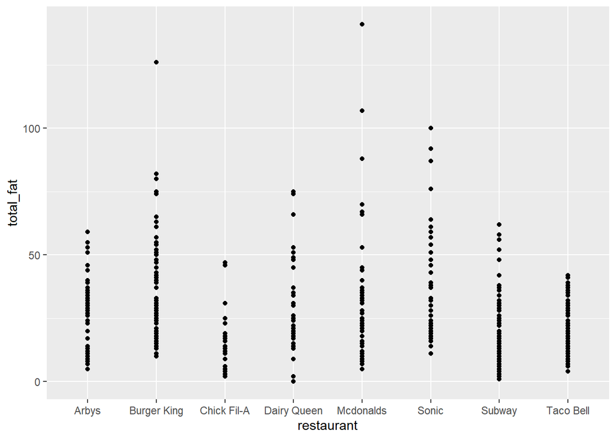

```r
ggplot(data = fastfood) +
  geom_point(mapping = aes(x = restaurant, y = total_fat))
```

## 2.9 Add a variable to the dataset, which calculates the sum of cholesterol and sodium and call it `cholesterol_sodium`.

Removing the variable `salad` by using the **rm()** function.

```r
# Add the variable 'cholesterol_sodium'
# Sum of cholesterol and sodium
fastfood <- fastfood_data %>%
  mutate(cholester_sodium = sum(cholesterol,
                                sodium,
                                na.rm = TRUE))  #na.rm = NA values should not be included
fastfood
```

```
## # A tibble: 515 × 19
##        X restaurant item            calories cal_fat total_fat sat_fat trans_fat
##    <dbl> <chr>      <chr>              <dbl>   <dbl>     <dbl>   <dbl>     <dbl>
##  1     1 Mcdonalds  Artisan Grille…      380      60         7       2       0
##  2     2 Mcdonalds  Single Bacon S…      840     410        45      17       1.5
##  3     3 Mcdonalds  Double Bacon S…     1130     600        67      27       3
##  4     4 Mcdonalds  Grilled Bacon …      750     280        31      10       0.5
##  5     5 Mcdonalds  Crispy Bacon S…      920     410        45      12       0.5
##  6     6 Mcdonalds  Big Mac              540     250        28      10       1
##  7     7 Mcdonalds  Cheeseburger         300     100        12       5       0.5
##  8     8 Mcdonalds  Classic Chicke…      510     210        24       4       0
##  9     9 Mcdonalds  Double Cheeseb…      430     190        21      11       1
## 10    10 Mcdonalds  Double Quarter…      770     400        45      21       2.5
## # … with 505 more rows, and 11 more variables: cholesterol <dbl>, sodium <dbl>,
## #   total_carb <dbl>, fiber <dbl>, sugar <dbl>, protein <dbl>, vit_a <dbl>,
## #   vit_c <dbl>, calcium <dbl>, salad <chr>, cholester_sodium <dbl>
```

```r
# remove the variable 'salad'
fastfood <- within(fastfood, rm(salad))
```

## 2.10 Use observations for Mcdonalds to plot sugar variable against protein with `geom_point()`

Using the script below, I have used the following functions:

- filter() -> to filter restaurants only containing the keyword “Mcdonalds”
- geom_point() -> adding ‘dots’ (data points) to the graph
- geom_line() -> connecting the dots to identify the common trend

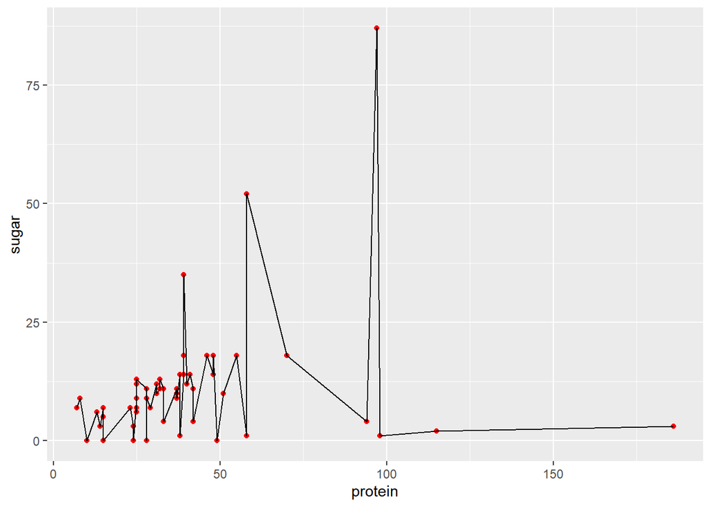

```r
fastfood %>%
  filter(restaurant == "Mcdonalds") %>%
  ggplot(aes(protein, sugar)) +
  geom_point(colour = "red") +
  geom_line()
```